# Análisis de Datos I Tarea 2

Se cargan las librerías necesarias.

```r
library(readr)
library(FactoMineR)
library(ggplot2)
library(dplyr)
library(gridExtra)
library(factoextra)
```

Para el desarrollo de los ejercicios se emplea la siguiente matriz:

```r
X <- matrix(c(8,1,0,4,6,5,6,8,7,10,4,7,8,2,5,0,3,6), nrow = 6, ncol = 3, byrow
            = TRUE)
```

Además, para el ejercicio 8 se utilizan las siguientes bases de datos:

```r
#----- Estudiantes--------
estudiantes_datos <- read.table('EjemploEstudiantes.csv', header=TRUE, sep=';',dec=',',row.names=1)
estudiantes_datos<- as.matrix(estudiantes_datos)

#----- beans--------------

beans_datos <- read.csv("beansV2.csv")
beans_datos <- as.matrix(beans_datos[,-17])
```

# Ejercicio 2

**Implemente en lenguaje R funciones que permitan ejecutar el algoritmo del Análisis en Componentes Principales (ACP) visto en clase para variables numéricas. Compare los resultados obtenidos con respecto a FactoMineR**

Primeramente, se construyen las siguientes funciones necesarias para plantear una función que realice un ACP de una base de datos.

```r
  #Obtner medias de las columnas de la matriz
medias <- function(matriz) {
  resultado <-list()
  for(i in 1:ncol(matriz)) {
    resultado[[i]] <- mean(matriz[,i])
  }
  return(resultado)
}
```

```r
#Obtener desviaciones estándar poblacionales de las columnas de la matriz
sd_poblacional <- function(matriz) {
  resultado <- list()
  n <- nrow(matriz)
  for(i in 1:ncol(matriz)) {
    resultado[[i]] <- sqrt(((n-1)/n))*sd(matriz[,i])
  }
  return(resultado)
}
```

```r
#Centramos y reducimos la matriz con la siguiente función
centrar_y_reducir <- function(matriz, medias, desviaciones) {

  for(i in 1 : ncol(matriz)){
    matriz[, i] <- (matriz[,i]-medias[[i]])/ desviaciones[[i]]
  }
  return(matriz)
}
```

```r
#Calcular la matriz de correlaciones
R <- function(matriz) {
  n <- nrow(matriz)
  resultado <- (1/n)*t(matriz)%*%matriz
  return(resultado)
}
```

```r
#Calcular la matriz de calidades de los individuos (cosenos cuadrados)
Q <- function(C, matriz) {
  n <-nrow(matriz)
  m <-ncol(matriz)
  resultado <- matrix(0, n,m)

  for(i in 1: n){
    suma <- 0
    for(j in 1: m){
      suma <- suma + matriz[i,j]^2
    }
    for(r in 1: m){
      resultado[i,r] <- (C[i,r]^2)/suma
    }
  }
  return(resultado)
}
```

```r
#Calcular la contribución de cada individuo i a la varianza total del eje r
contribucion <- function(C, valores.propios) {
  n <-nrow(C)
  m <-ncol(C)
  resultado <- matrix(0, n, m)

  for(i in 1: n){
    for(r in 1: m){
      resultado[i,r] <- ((C[i,r]^2)/(n*valores.propios[r]))*100
    }
  }
  return(resultado)
}
```

```r
# Calcular la matriz de coordenadas T de las variables
T <- function(V, valores.propios){
  m <- ncol(V)
  resultado <- matrix(0, m, m)

  for(r in 1:m){
      resultado[,r] <- sqrt(valores.propios[r])*V[,r]
    }

  return(resultado)
}
```

```r
#Calcular vector de inercias de los ejes
I <- function(valores.propios){
  m <- length(valores.propios)
  resultado <- c()

  for(j in 1: m){
    resultado[j] <-100*(valores.propios[j]/m)
  }
  return(resultado)
}
```

Usamos la funciones anteriores para construir una sola función que retorne el ACP de una base de datos.

```r
ACP_funcion <- function(X){
  #1) centrar y reducir X
  medias_X <- medias(X)
  sd_X <- sd_poblacional(X)
  X <- centrar_y_reducir(X,medias_X, sd_X)

  #2) matriz de correlaciones
  X_R <- R(X)

  #3y 4) valores y vectores propios de la matriz de correlaciones
  X.R_e <- eigen(X_R)
  X.R_valores.propios <- X.R_e$values #ya vienen ordenados de mayor a menor
  X.R_vectores.propios <- X.R_e$vectors
  X.R_vectores.propios

  #5) Construir matriz V que tiene como columnas los vectores propios de la matriz de correlaciones
  V <- X.R_vectores.propios

  #6) Calcular la matriz de componentes principales
  C <- X%*%V

  #7) Calcular la matriz de calidades de los individuos
  X_Q <- Q(C, X)

  # La matriz de contribuciones para los individuos de X es:
  X_contrib <- contribucion(C, X.R_valores.propios)

  #8) La matriz de coordenadas de las variables
  X_T <- T(V, X.R_valores.propios)

  #9) Matriz de calidades de las variables
  S <- X_T^2

  #10) Vector de inercias
  X_I <- I(X.R_valores.propios)

  resultado <- list(valores_propios = X.R_valores.propios,ind_coord = C, ind_cos2 = X_Q, ind_contrib = X_contrib,
                    var_coord = X_T, var_cos2 = S, inercias = X_I)
}
```

Comparamos los resultados obtenidos con los de FactoMiner para la matriz X.

**Valores propios**

```r
ACP_X <- ACP_funcion(X)
ACP_X$valores_propios
```

```
## [1] 1.7278743 0.9191845 0.3529412
```

Comparamos con lo obtenido con FactoMiner

```r
X_ACP <- PCA(X, ncp = 4, graph = FALSE)
X_ACP$eig
```

```
##        eigenvalue percentage of variance cumulative percentage of variance
## comp 1  1.7278743               57.59581                          57.59581
## comp 2  0.9191845               30.63948                          88.23529
## comp 3  0.3529412               11.76471                         100.00000
```

Se puede observar que los valores propios obtenidos con FactoMiner son iguales a los del algoritmo.

**Coordenadas de los individuos**

```r
ACP_X$ind_coord
```

```
##            [,1]       [,2]       [,3]
## [1,]  2.4480754 -0.1702518 -0.5940885
## [2,] -0.7572077 -0.3931637 -0.5940885
## [3,] -1.6908677  0.5634155 -0.5940885
## [4,] -0.1764523  1.3497428  0.5940885
## [5,]  0.7572077  0.3931637  0.5940885
## [6,] -0.5807554 -1.7429065  0.5940885
```

Con FactoMiner se obtiene lo siguiente:

```r
X_ACP$ind$coord
```

```
##        Dim.1      Dim.2      Dim.3
## 1 -2.4480754 -0.1702518  0.5940885
## 2  0.7572077 -0.3931637  0.5940885
## 3  1.6908677  0.5634155  0.5940885
## 4  0.1764523  1.3497428 -0.5940885
## 5 -0.7572077  0.3931637 -0.5940885
## 6  0.5807554 -1.7429065 -0.5940885
```

Podemos observar que lo único que varía es el signo de algunas entradas, pero esto solo indica que se refleja con respecto a algunos de los ejes al graficar.

**Matriz de cosenos al cuadrado de los individuos**

```r
ACP_X$ind_cos2
```

```
##            [,1]        [,2]       [,3]
## [1,] 0.94008991 0.004546772 0.05536332
## [2,] 0.53045874 0.143010648 0.32653061
## [3,] 0.81005952 0.089940481 0.10000000
## [4,] 0.01411472 0.825885276 0.16000000
## [5,] 0.53045874 0.143010648 0.32653061
## [6,] 0.09047267 0.814852770 0.09467456
```

Vemos los resultados de FactoMiner

```r
X_ACP$ind$cos2
```

```
##        Dim.1       Dim.2      Dim.3
## 1 0.94008991 0.004546772 0.05536332
## 2 0.53045874 0.143010648 0.32653061
## 3 0.81005952 0.089940481 0.10000000
## 4 0.01411472 0.825885276 0.16000000
## 5 0.53045874 0.143010648 0.32653061
## 6 0.09047267 0.814852770 0.09467456
```

Los cuales son iguales a los obtenidos con el algoritmo.

**Constribución de los individuos**

```r
ACP_X$ind_contrib
```

```
##            [,1]       [,2]     [,3]
## [1,] 57.8077648  0.5255686 16.66667
## [2,]  5.5305285  2.8028049 16.66667
## [3,] 27.5775612  5.7557722 16.66667
## [4,]  0.3003249 33.0330084 16.66667
## [5,]  5.5305285  2.8028049 16.66667
## [6,]  3.2532922 55.0800411 16.66667
```

Con FactoMiner se tiene:

```r
X_ACP$ind$contrib
```

```
##        Dim.1      Dim.2    Dim.3
## 1 57.8077648  0.5255686 16.66667
## 2  5.5305285  2.8028049 16.66667
## 3 27.5775612  5.7557722 16.66667
## 4  0.3003249 33.0330084 16.66667
## 5  5.5305285  2.8028049 16.66667
## 6  3.2532922 55.0800411 16.66667
```

Por lo tanto, se tiene el mismo resultado que FactoMiner.

**Coordenadas de las variables** La matriz de coordenadas de las variables para los datos que tenemos es:

```r
ACP_X$var_coord
```

```
##            [,1]      [,2]          [,3]
## [1,]  0.4155396 0.9095751 -6.164154e-17
## [2,] -0.8818166 0.2143101 -4.200840e-01
## [3,] -0.8818166 0.2143101  4.200840e-01
```

Y la dada con FactoMiner es:

```r
X_ACP$var$coord
```

```
##         Dim.1     Dim.2     Dim.3
## V1 -0.4155396 0.9095751  0.000000
## V2  0.8818166 0.2143101  0.420084
## V3  0.8818166 0.2143101 -0.420084
```

**Matriz de cosenos al cuadrado de las variables**

```r
ACP_X$var_cos2
```

```
##           [,1]       [,2]         [,3]
## [1,] 0.1726732 0.82732684 3.799680e-33
## [2,] 0.7776006 0.04592883 1.764706e-01
## [3,] 0.7776006 0.04592883 1.764706e-01
```

Con FactoMiner da:

```r
X_ACP$var$cos2
```

```
##        Dim.1      Dim.2     Dim.3
## V1 0.1726732 0.82732684 0.0000000
## V2 0.7776006 0.04592883 0.1764706
## V3 0.7776006 0.04592883 0.1764706
```

Por temas computacionales, el primer valor de la tercera dimensión de la matriz de coordenadas y calidades de las variables, obtenida con el algoritmo, es muy cercano a cero. Por lo cual, con FactoMiner aparece como cero.

**Inercias**

```r
ACP_X$inercias[1:2]
```

```
## [1] 57.59581 30.63948
```

Con FactoMiner se tiene:

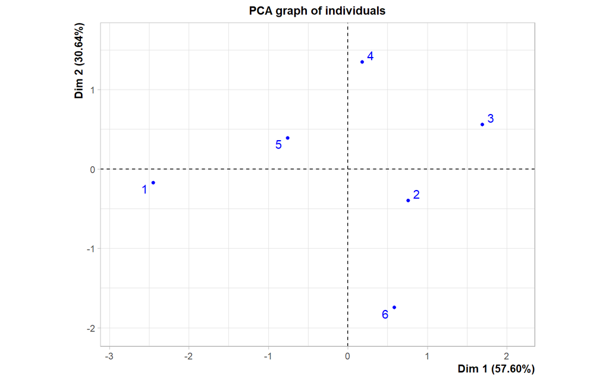

```r
plot(X_ACP, axes=c(1, 2), choix="ind", col.ind="blue",new.plot=TRUE)
```

Podemos observar que las inercias correpondiente al eje “x” y “y” obtenidas con FactoMiner son iguales a las dadas por el algoritmo.

# Ejercicio 3

**Implemente en lenguaje R funciones que grafiquen el plano principal (en 2 dimensiones),el círculo de correlaciones (en 2 dimensiones) que incluya la inercia, el gráfico dual (en 2D) para ver ambos gráficos juntos. Compare los resultados obtenidos con respecto a FactoMineR**

A continuación se presentan las funciones para calcular dichos gráficos

```r
#---------------------------Plano principal individuos--------------------------

plano_principal <- function(matriz){
  #Obtenemos la matriz con las coordenadas de los individuos

  ACP_matriz <- ACP_funcion(matriz)
  C <- ACP_matriz$ind_coord

  #Convertimos la matriz en un dataframe
  C_data <- as.data.frame(C)
  col_names <- paste("Dim", 1:ncol(C_data))  # Genera nombres como "Dim 1", "Dim 2", etc.
  colnames(C_data) <- col_names

  if(is.null(rownames(C_data))) {
    C_data$individuo <- seq_len(nrow(C_data))
  } else {
    C_data$individuo <- rownames(C_data)
  }

  #Sacamos la inercia
  X_I <- ACP_matriz$inercias
  X_I_redondeados <- round(X_I, 2)
  inercia <- X_I_redondeados[1] + X_I_redondeados[2]


  #Graficamos

  if(nrow(C_data) <= 10){
    individuos <- ggplot(C_data, aes(x = `Dim 1`, y = `Dim 2`)) +
      geom_point(color = "lightblue") +
      geom_text(aes(label = individuo), vjust = 0, hjust = 0,
                color = "lightblue") +
      labs(x = paste("Dim 1 (", X_I_redondeados[1], "%)"),
         y = paste("Dim 2 (", X_I_redondeados[2], "%)"),
         subtitle = paste("Inercia = ", inercia, "%"), title = "Plano principal (Individuos)")+
      theme_minimal()
  }else{
    individuos <- ggplot(C_data, aes(x = `Dim 1`, y = `Dim 2`)) +
      geom_point(color = "lightblue") +
      labs(x = paste("Dim 1 (", X_I_redondeados[1], "%)"),
         y = paste("Dim 2 (", X_I_redondeados[2], "%)"),
         subtitle = paste("Inercia = ", inercia, "%"), title = "Plano principal (Individuos)") +
      theme_minimal()
  }

  return(individuos)
}
```

```r
#----------------------------Círculo de correlaciones---------------------------
circulo_correlaciones <- function(matriz){
  #Obtenemos la matriz con las coordenadas de las variables

  ACP_matriz <- ACP_funcion(matriz)

  X_T <- ACP_matriz$var_coord

  #Convertimos la matriz en un dataframe y ajustamos para el gráfico
  X_T_data <- as.data.frame(X_T)

  col_names <- paste("Dim", 1:ncol(X_T_data))  # Genera nombres como "Dim 1", "Dim 2", etc.
  colnames(X_T_data) <- col_names

  if(is.null(colnames(matriz))) {
    X_T_data$variable <- seq_len(ncol(matriz))
  } else {
    X_T_data$variable <- colnames(matriz)
  }
  X_T_data$`x origen` <- 0
  X_T_data$`y origen` <- 0

  #Sacamos la inercia
  X_I <- ACP_matriz$inercias
  X_I_redondeados <- round(X_I, 2)
  inercia <- X_I_redondeados[1] + X_I_redondeados[2]

  #Graficamos
  variables0 <- ggplot(X_T_data, aes(x = `x origen`, y = `y origen`)) +
    geom_segment(aes(xend = `Dim 1`, yend = `Dim 2`),
                 arrow = arrow(length = unit(0.2, "inches")), color = "orange") +
    geom_text(aes(x = `Dim 1`, y = `Dim 2`, label = variable), vjust = -0.5,
              nudge_y = 0, nudge_x = 0, color ="orange") +
    labs(x = paste("Dim 1 (", X_I_redondeados[1], "%)"),
         y = paste("Dim 2 (", X_I_redondeados[2], "%)"),
         subtitle = paste("Inercia = ", inercia, "%")) +
    theme_minimal()

  variables <- variables0 +
    geom_path(data = data.frame(x = cos(seq(0, 2 * pi, length.out = 100)),
                                y = sin(seq(0, 2 * pi, length.out = 100))),
              aes(x, y), color = "black", linewidth = 1, linetype = "dashed") +
    labs(title = "Círculo de correlaciones")

  return(list(variables0 = variables0, variables = variables))
}
```

```r
#---------------------------Grafico Dual----------------------------------------
grafico_dual <- function(graf_ind, graf_var, matriz) {
  # Obtener los graficos y las etiquetas
  grafico_circulo <- graf_var$variables0
  data_graf_ind <- ggplot_build(graf_ind)$data[[1]]
  data_graf_var <-ggplot_build(grafico_circulo)$data[[1]]

  if(is.null(rownames(matriz))) {
    data_graf_ind$label <- seq_len(nrow(matriz))
  } else {
    data_graf_ind$label <- rownames(matriz)
  }

  if (is.null(colnames(matriz))){
    data_graf_var$label <- seq_len(ncol(matriz))
  }else {
    data_graf_var$label <- colnames(matriz)
  }

  # Superponer los gráficos
  if(nrow(data_graf_ind) <= 10){
    grafico_final <- grafico_circulo +
      geom_point(data = data_graf_ind, aes(x, y), color = "lightblue") +
      geom_text(data = data_graf_ind, aes(x, y, label = label),
                vjust = 0, hjust = 0, color = "lightblue")
  }else{
    #grafico_final <- grafico_circulo +
      #geom_point(data = data_graf_ind, aes(x, y), color = "lightblue", size=1)
    grafico_final <- graf_ind +
      geom_segment(data = data_graf_var, aes(x = x, y = y, xend =  xend, yend = yend),
                   arrow = arrow(length = unit(0.2, "inches")), color = "orange")+
      geom_text(data = data_graf_var, aes(x = xend, y = yend, label =label),
                vjust = 0, hjust = 0, color = "orange" )
  }

  return(grafico_final)
}
```

Ahora, comparamos los gráficos obtenidos con el algoritmo para la matriz X y los dados por FactoMiner.

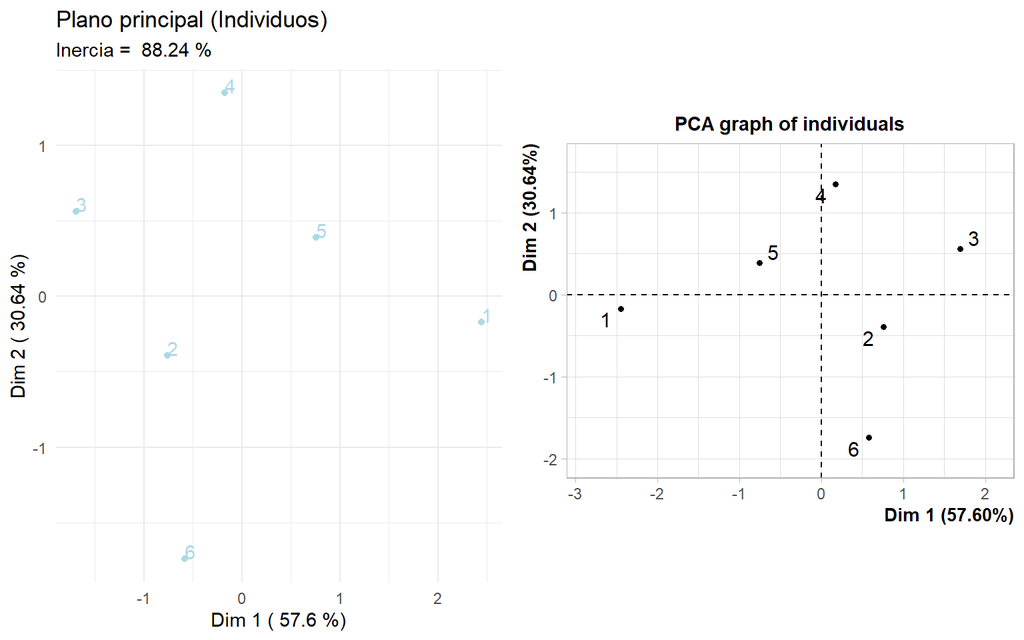

```r
individuos_FM <- plot(X_ACP)

grid.arrange(plano_principal(X), individuos_FM, ncol = 2)
```

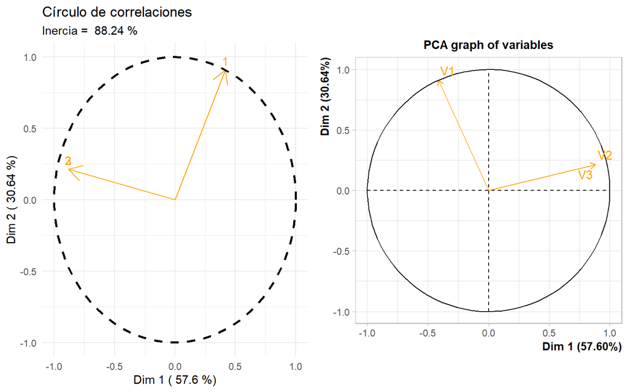

```r
variables_FM <- plot(X_ACP, axes=c(1, 2), choix="var", col.var="orange",
                     new.plot=TRUE)

grid.arrange(circulo_correlaciones(X)[["variables"]], variables_FM, ncol = 2)
```

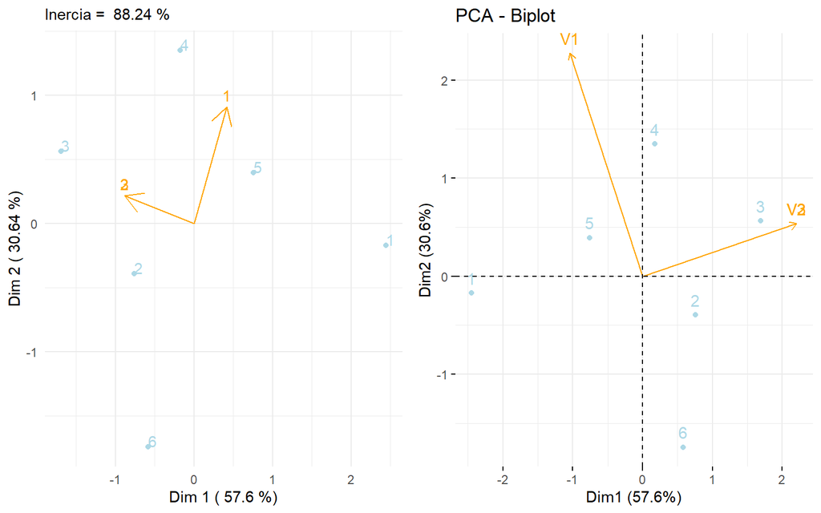

```r
dual_FM <- fviz_pca_biplot(X_ACP,col.var = "orange",col.ind = "lightblue")
grid.arrange(grafico_dual(plano_principal(X), circulo_correlaciones(X), X),
             dual_FM, ncol = 2)
```

Como se puede observar, todos los gráficos generados por FactoMiner están reflejados con respecto al eje “y” en comparación con los generados por el algortimo .

# Ejercicio 4

**Programe una función en R que reciba una fila (individuo) de una matriz y calcule la proyección en suplementario de este individuo en el plano principal 2D programado en el punto anterior. Compare los resultados obtenidos con respecto a FactoMineR**

Primeramente, es necesario mencionar que el individuo suplementario se considera como una nueva fila que se le añade a la base de datos inicial. Por lo tanto, en caso de que la fila no tenga una etiqueta, se le coloca un identificador que corresponde al número de fila, en este caso, el último.

La función es la siguiente:

```r
ind.sup_proyeccion <- function(fila, matriz) {
  #se calcula la media y desviación estándar de cada columna
  medias <- medias(matriz)
  sd <-sd_poblacional(matriz)

  #centramos y reducimos la fila y la matriz

  for(i in 1:length(fila)){
    fila[i] <- (fila[i]-medias[[i]])/sd[[i]]
  }

  matriz <- centrar_y_reducir(matriz, medias, sd)

  #Matriz de correlaciones
  correlaciones <- R(matriz)
  #Vectores propios
  matriz.e <- eigen(correlaciones)
  V <- matriz.e$vectors

  #Se calcula las coordenadas
  C <- fila%*%V

  #Se gráfica esas coordenadas en el plano

  #Convertimos la fila en un dataframe
  C_data_ind <- as.data.frame(C)
  col_names <- paste("Dim", 1:ncol(C_data_ind))  # Genera nombres como "Dim 1", "Dim 2", etc.
  colnames(C_data_ind) <- col_names

  if(is.null(rownames(fila))){
    C_data_ind$individuo <- nrow(matriz) + 1
  }else {
    C_data_ind$individuo <- rownames(fila)
  }

  resultado <- plano_principal(matriz) + geom_point(data = C_data_ind, aes(x = `Dim 1`, y = `Dim 2`),
                                                    color = "red")+
    geom_text(data = C_data_ind, aes(x = `Dim 1`, y = `Dim 2`),
              vjust = -0.5, hjust = -0.5, color = "red", label = C_data_ind$individuo )
  return(resultado)

}
```

Comparamos la proyección suplementaria del individuo en el plano inicial que da esta función con el resultado de FactoMiner. Para esto, tomamos como individuo suplementario a la fila número 6 de la matriz X.

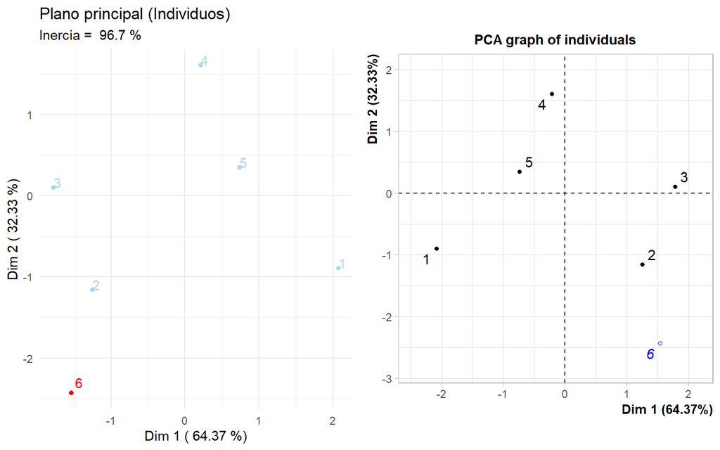

```r
fila <- X[6,]
coordenadasind_sup <- ind.sup_proyeccion(fila, X[-6,])

ACP_indsup <- PCA( X,ind.sup = 6, graph = F)
coordenadasind_sup_FM <-plot.PCA(ACP_indsup, choix = "ind")

grid.arrange(coordenadasind_sup, coordenadasind_sup_FM, ncol = 2)
```

Podemos observar que los gráficos se encuentran reflejados con respecto al eje “y”. Además, el punto de color distinto, en cada gráfico, corresponde al individuo suplementario. También, es posible notar que al agregar la proyección suplementaria no se alteran las coordenadas de los individuos iniciales.

# Ejercicio 5

**Programe una función en R que reciba una columna (variable) de una matriz y calcule su proyección en suplementario en el círculo de correlaciones 2D programado en el punto2. Compare los resultados obtenidos con respecto a FactoMineR.**

Primeramente, es necesario mencionar que la variable suplementaria se considera como una nueva columna que se le añade a la base de datos inicial. Por lo tanto, en caso de que la columna no tenga una etiqueta, se le coloca un identificador que corresponde al número de columna, en este caso, el último.

La función es la siguiente:

```r
var.sup_proyeccion <- function(columna, matriz) {
  #se calcula la media y desviación estándar de la columna
  media <- mean(columna)
  n <- length(columna)
  sd <-sqrt(((n-1)/n))*sd(columna)

  #Se obtienen los componentes principales
  ACP_matriz <- ACP_funcion(matriz)
  C <- ACP_matriz$ind_coord

  #Se calculan las correlaciones de la columna con los componentes principales
  coordenada <- c()
  for(i in 1: ncol(matriz)){
    coordenada[i] <-cor(columna, C[,i])
  }
  #Se gráfica en el círculo de correlaciones
  circulo <- circulo_correlaciones(matriz)
  graf_circulo <- circulo$variables

  #Convertimos la matriz en un dataframe y ajustamos para el gráfico
  coordenada_var <- as.data.frame(t(coordenada))
  col_names <- paste("Dim", 1:ncol(coordenada_var))  # Genera nombres como "Dim 1", "Dim 2", etc.
  colnames(coordenada_var) <- col_names
  coordenada_var$`x origen` <- 0
  coordenada_var$`y origen` <- 0

  if(is.null(colnames(columna))){
   coordenada_var$variable <- ncol(matriz) + 1
  }else {
    coordenada_var$variable <- colnames(columna)
  }

  resultado <- graf_circulo +
    geom_segment(data = coordenada_var, aes(x = `x origen`, y = `y origen`, xend = `Dim 1`, yend = `Dim 2`),
    arrow = arrow(length = unit(0.2, "inches")), color = "red")+
    geom_text(data = coordenada_var, aes(x = `Dim 1`, y = `Dim 2`),
              vjust = -0.5, hjust = -0.5, color = "red", label = coordenada_var$variable )
  return(resultado)
}
```

Para comparar con FactoMiner, tomamos como variable suplementaria a la columna 3.

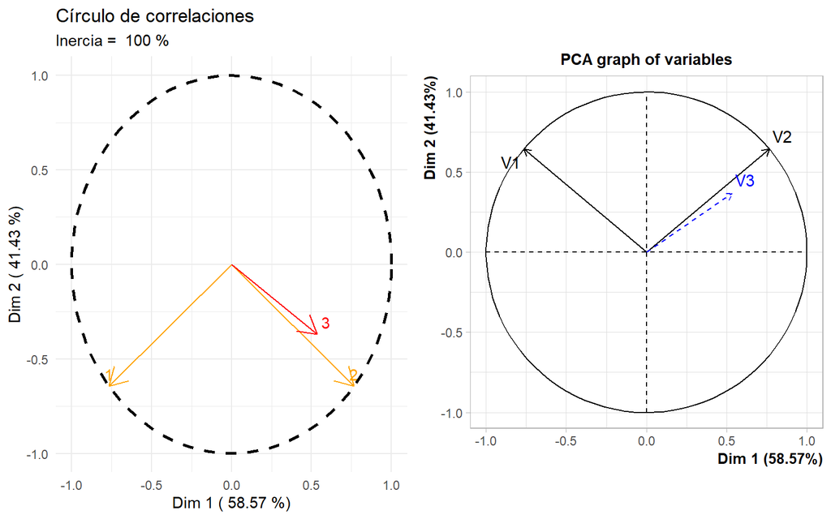

```r
columna <- X[,3]
coordenadasvar_sup <- var.sup_proyeccion(columna, X[,-3])

ACP_varsup <- PCA( X,quanti.sup = 3, graph = F)
coordenadasvar_sup_FM <- plot.PCA(ACP_varsup, choix = "var")

grid.arrange(coordenadasvar_sup, coordenadasvar_sup_FM, ncol = 2)
```

Para el caso de la variable suplementaria, se puede ver que los gráficos se encuentran reflejados con respecto al eje x. También, el vector con distinto color, en cada gráfico, corresponde a la variable suplementaria. Además, es posible observar que al agregar la proyección suplementaria no se alteran las coordenadas de las variables iniciales.

# Ejercicio 8

**Verifique todo lo programado en los puntos anteriores con el ejemplo estudiantes.csv y con los datos del ejercicio 1 de la tarea anterior.**

## Base de datos de estudiantes

### Inciso 2

```r
ACP_estudiantes <- ACP_funcion(estudiantes_datos)
ACP_estudiantes
```

```
## $valores_propios
## [1] 2.893249673 1.628650425 0.346596049 0.122612460 0.008891393
##
## $ind_coord
##               [,1]       [,2]        [,3]        [,4]         [,5]
## Lucia  -0.32306263 -1.7725245  1.19880074 -0.05501532  0.003633384
## Pedro  -0.66544057  1.6387021  0.14547628 -0.02306468 -0.123377296
## Ines   -1.00254705  0.5156925  0.62888764  0.51644351  0.142875824
## Luis    3.17209481  0.2627820 -0.38196027  0.67777691 -0.062503554
## Andres  0.48886797 -1.3654021 -0.83523570 -0.15579197  0.123367255
## Ana    -1.70863322  1.0217004 -0.12707707  0.06683295  0.025291503
## Carlos -0.06758577 -1.4623364 -0.50624044 -0.11792847  0.013123980
## Jose   -2.01185516  1.2758646 -0.54215002 -0.19778670  0.017434170
## Sonia   3.04203029  1.2548807  0.44882861 -0.63999876  0.037884840
## Maria  -0.92386867 -1.3693593 -0.02932977 -0.07146746 -0.177730107
##
## $ind_cos2
##              [,1]        [,2]        [,3]         [,4]         [,5]
##  [1,] 0.022270827 0.670420670 0.306659839 0.0006458478 2.816992e-06
##  [2,] 0.139905502 0.848430539 0.006686527 0.0001680781 4.809354e-03
##  [3,] 0.514468899 0.136122895 0.202439714 0.1365196756 1.044882e-02
##  [4,] 0.936851990 0.006429392 0.013583605 0.0427712757 3.637375e-04
##  [5,] 0.084139511 0.656353715 0.245603703 0.0085448999 5.358172e-03
##  [6,] 0.732686110 0.261979570 0.004052795 0.0011209894 1.605349e-04
##  [7,] 0.001892733 0.886081139 0.106192189 0.0057625700 7.136907e-05
##  [8,] 0.673612108 0.270910359 0.048916504 0.0065104446 5.058468e-05
##  [9,] 0.808829929 0.137636943 0.017607237 0.0358004434 1.254472e-04
## [10,] 0.308554271 0.677869212 0.000310977 0.0018464085 1.141913e-02
##
## $ind_contrib
##              [,1]       [,2]        [,3]        [,4]        [,5]
##  [1,]  0.36073437 19.2910834 41.46392357  0.24684974  0.01484748
##  [2,]  1.53049754 16.4881591  0.61060555  0.04338706 17.11987788
##  [3,]  3.47395038  1.6328779 11.41096846 21.75259335 22.95871968
##  [4,] 34.77814436  0.4239976  4.20932799 37.46613853  4.39379307
##  [5,]  0.82603273 11.4470414 20.12771563  1.97950024 17.11709152
##  [6,] 10.09047896  6.4094282  0.46591936  0.36428947  0.71941493
##  [7,]  0.01578791 13.1300601  7.39418080  1.13423412  0.19371414
##  [8,] 13.98967133  9.9949649  8.48038057  3.19050613  0.34184774
##  [9,] 31.98461714  9.6688984  5.81215853 33.40593699  1.61421395
## [10,]  2.95008527 11.5134890  0.02481953  0.41656436 35.52647960
##
## $var_coord
##            [,1]       [,2]        [,3]        [,4]        [,5]
## [1,] -0.8957980  0.3452036  0.25797931 -0.09146818  0.05882803
## [2,] -0.7227976  0.6483946  0.02384033  0.23587773 -0.03068234
## [3,] -0.6108931 -0.7173206  0.33102532 -0.02454152 -0.04561456
## [4,] -0.5999227 -0.7484701 -0.23206345  0.15639747  0.03964443
## [5,]  0.9139265 -0.1196373  0.34065108  0.18315368  0.02892890
##
## $var_cos2
##           [,1]       [,2]         [,3]         [,4]         [,5]
## [1,] 0.8024540 0.11916550 0.0665533242 0.0083664287 0.0034607374
## [2,] 0.5224364 0.42041555 0.0005683612 0.0556383052 0.0009414059
## [3,] 0.3731904 0.51454884 0.1095777630 0.0006022863 0.0020806881
## [4,] 0.3599073 0.56020745 0.0538534429 0.0244601695 0.0015716811
## [5,] 0.8352616 0.01431309 0.1160431572 0.0335452699 0.0008368811
##
## $inercias
## [1] 57.8649935 32.5730085  6.9319210  2.4522492  0.1778279
```

### Inciso 3

**Plano principal**

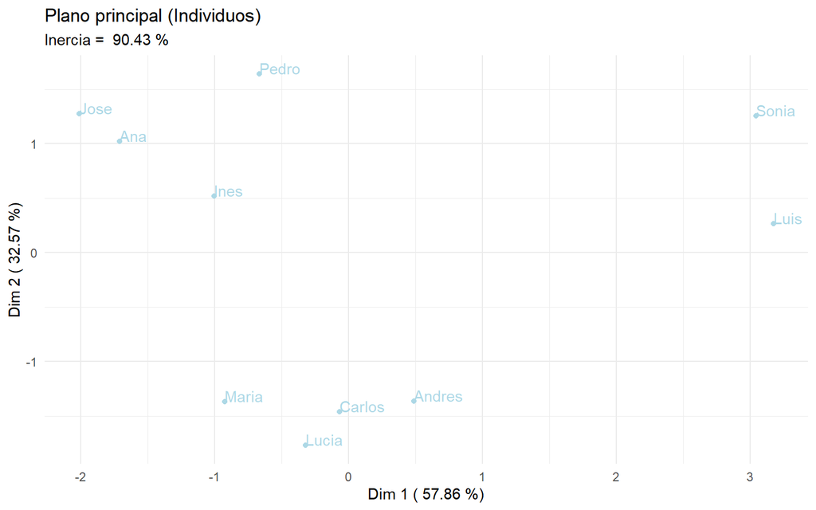

```r
plano_principal(estudiantes_datos)
```

**Círculo de correlaciones**

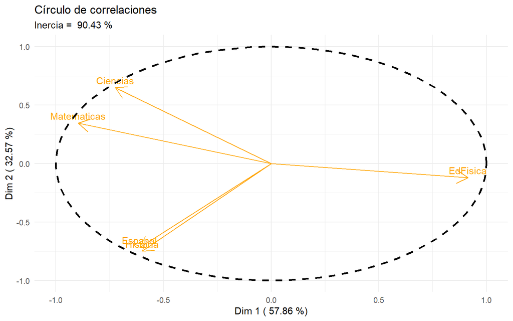

```r
circulo_correlaciones(estudiantes_datos)$variables
```

**Gráfico Dual**

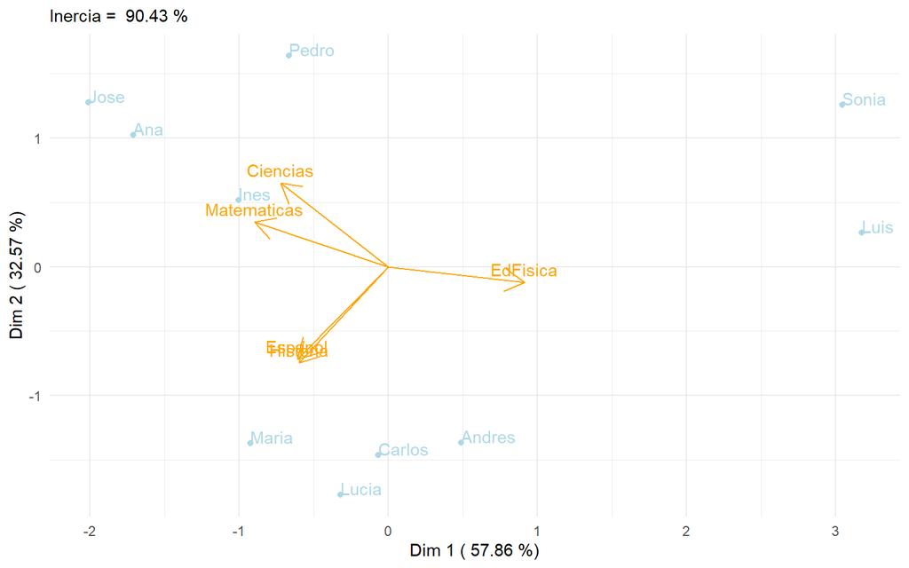

```r
grafico_dual(plano_principal(estudiantes_datos),
             circulo_correlaciones(estudiantes_datos), estudiantes_datos)
```

### Inciso 4

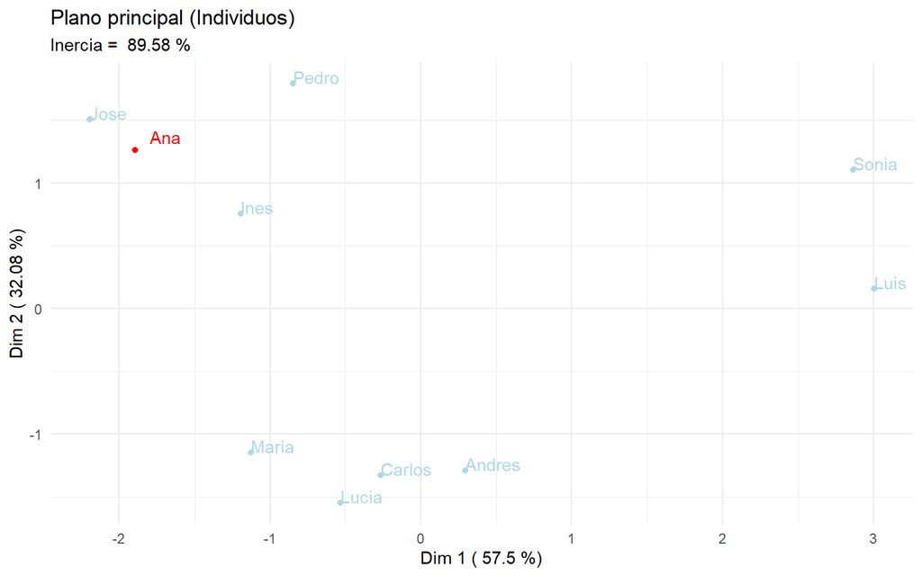

```r
fila_sup_estudiantes <- as.matrix(estudiantes_datos[6,])
colnames(fila_sup_estudiantes) <- (rownames(estudiantes_datos))[6]
fila_sup_estudiantes <- t(fila_sup_estudiantes)

coordenadasind_sup_estudiantes <- ind.sup_proyeccion(fila_sup_estudiantes, estudiantes_datos[-6,])
coordenadasind_sup_estudiantes
```

### Inciso 5

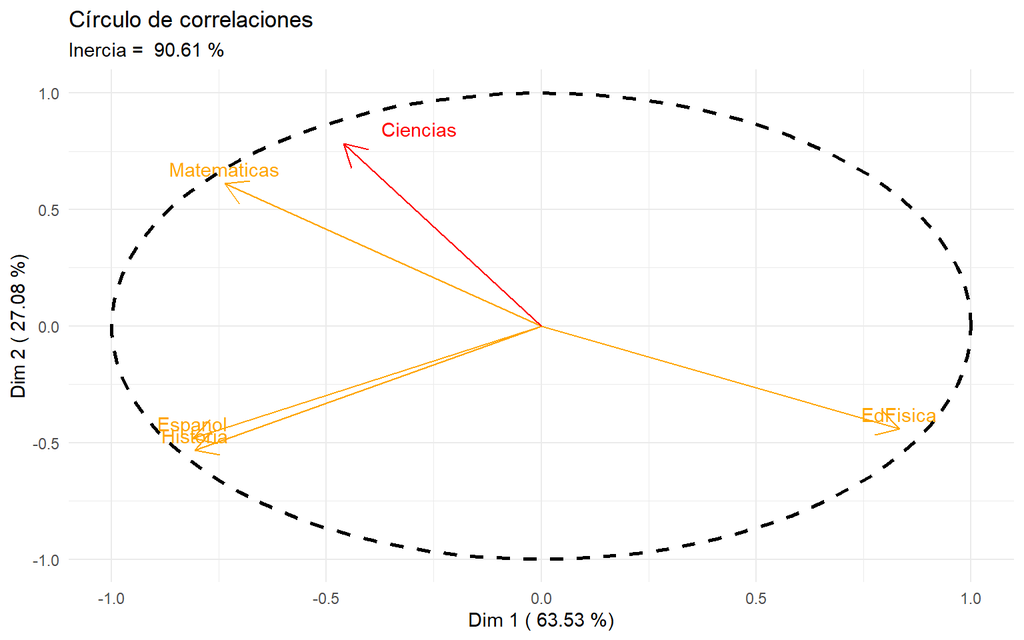

```r
columna_sup_estudiantes <- as.matrix(estudiantes_datos[,2])
colnames(columna_sup_estudiantes) <- (colnames(estudiantes_datos))[2]

coordenadasvar_sup_estudiantes <- var.sup_proyeccion(columna_sup_estudiantes, estudiantes_datos[,-2])
coordenadasvar_sup_estudiantes
```

## Base de datos beans

```r
ACP_beans <- ACP_funcion(beans_datos)
head(ACP_beans$ind_coord)
```

```
##          [,1]     [,2]       [,3]        [,4]       [,5]        [,6]      [,7]
## [1,] 4.954396 2.380180 0.71730093 -0.30338913 -0.2744232  0.05329105 0.7853845
## [2,] 4.795969 2.222327 0.24715079 -0.04858545  0.1349379  0.08002317 0.4857846
## [3,] 5.257747 3.018605 0.82169386 -0.34956228 -0.2694721 -0.09725266 0.9946442
## [4,] 5.278028 3.011816 0.83690246 -0.54782544 -0.1164945 -0.05513674 0.8887121
## [5,] 4.683129 2.149465 0.02719566 -0.30158212  0.4825913 -0.10813236 0.5606352
## [6,] 4.070767 1.912148 2.55663303 -0.47689928 -1.2666939  0.27713777 0.7012274
##            [,8]       [,9]        [,10]         [,11]       [,12]        [,13]
## [1,] -0.2653867 -0.1861636  0.001207107  0.0154488237 0.043258663 -0.030175431
## [2,] -0.3009325 -0.1671529 -0.025111206 -0.0055807272 0.010411321 -0.031279265
## [3,] -0.4334570 -0.1310330  0.025174427  0.0742607546 0.037485883 -0.036942639
## [4,] -0.5241189 -0.1239362  0.017828579  0.0771151844 0.027301345 -0.039794276
## [5,] -0.1252299 -0.1552412 -0.024687865 -0.0075364485 0.003005016 -0.028865554
## [6,] -0.3257934 -0.1504145  0.050091286 -0.0009847665 0.084776711 -0.003489534
##              [,14]        [,15]         [,16]
## [1,] -1.473082e-03 0.0025819543  0.0001841148
## [2,]  7.498848e-04 0.0021115737  0.0004096177
## [3,] -1.084412e-03 0.0010731647 -0.0008334744
## [4,]  2.668886e-04 0.0007180304 -0.0007525761
## [5,] -3.314179e-04 0.0020406157 -0.0003828493
## [6,] -2.255225e-05 0.0013615449  0.0001527688
```

```r
head(ACP_beans$ind_cos2)
```

```
##           [,1]      [,2]         [,3]         [,4]         [,5]         [,6]
## [1,] 0.7762586 0.1791615 1.627151e-02 2.910885e-03 0.0023815882 8.981184e-05
## [2,] 0.8103520 0.1739951 2.152014e-03 8.316363e-05 0.0006414884 2.256070e-04
## [3,] 0.7117633 0.2346112 1.738426e-02 3.146193e-03 0.0018696649 2.435225e-04
## [4,] 0.7136709 0.2323869 1.794338e-02 7.688454e-03 0.0003476688 7.788194e-05
## [5,] 0.8050166 0.1695873 2.714762e-05 3.338441e-03 0.0085485329 4.291844e-04
## [6,] 0.5655144 0.1247770 2.230633e-01 7.761482e-03 0.0547563701 2.621095e-03
##             [,7]         [,8]         [,9]        [,10]        [,11]
## [1,] 0.019506963 0.0022273243 0.0010960103 4.608041e-08 7.547722e-06
## [2,] 0.008313972 0.0031905030 0.0009843489 2.221551e-05 1.097243e-06
## [3,] 0.025472507 0.0048375812 0.0004420768 1.631757e-05 1.419891e-04
## [4,] 0.020233770 0.0070374318 0.0003935059 8.143068e-06 1.523472e-04
## [5,] 0.011537010 0.0005756371 0.0008845991 2.237173e-05 2.084808e-06
## [6,] 0.016780659 0.0036222296 0.0007720954 8.562797e-05 3.309465e-08
##             [,12]        [,13]        [,14]        [,15]        [,16]
## [1,] 5.917949e-05 2.879599e-05 6.862442e-08 2.108250e-07 1.072019e-09
## [2,] 3.818851e-06 3.446943e-05 1.981117e-08 1.570846e-07 5.911238e-09
## [3,] 3.618026e-05 3.513921e-05 3.027785e-08 2.965302e-08 1.788631e-08
## [4,] 1.909513e-05 4.056914e-05 1.824798e-09 1.320810e-08 1.450960e-08
## [5,] 3.314562e-07 3.058387e-05 4.031664e-09 1.528463e-07 5.380073e-09
## [6,] 2.452700e-04 4.155528e-07 1.735685e-11 6.326380e-08 7.964537e-10
```

```r
head(ACP_beans$ind_contrib)
```

```
##            [,1]       [,2]         [,3]         [,4]         [,5]         [,6]
## [1,] 0.05822323 0.02806734 8.326456e-03 2.388037e-03 0.0035040549 0.0003160622
## [2,] 0.05455915 0.02446796 9.885108e-04 6.124257e-05 0.0008472216 0.0007126815
## [3,] 0.06557138 0.04514340 1.092641e-02 3.170226e-03 0.0033787563 0.0010526087
## [4,] 0.06607821 0.04494058 1.133462e-02 7.786198e-03 0.0006314521 0.0003383344
## [5,] 0.05202201 0.02288983 1.196897e-05 2.359675e-03 0.0108364815 0.0013012939
## [6,] 0.03930677 0.01811444 1.057777e-01 5.900575e-03 0.0746573620 0.0085478212
##            [,7]       [,8]       [,9]        [,10]        [,11]        [,12]
## [1,] 0.11510987 0.02727370 0.08745292 2.115242e-05 5.053034e-03 0.1332273414
## [2,] 0.04403880 0.03506903 0.07050384 9.153852e-03 6.593909e-04 0.0077171843
## [3,] 0.18462201 0.07275750 0.04332577 9.200003e-03 1.167562e-01 0.1000420695
## [4,] 0.14739072 0.10637639 0.03875979 4.614261e-03 1.259045e-01 0.0530658665
## [5,] 0.05865549 0.00607298 0.06081331 8.847810e-03 1.202527e-03 0.0006428961
## [6,] 0.09176259 0.04110270 0.05709058 3.642446e-02 2.053184e-05 0.5116821987
##            [,13]        [,14]       [,15]        [,16]
## [1,] 0.126389458 5.389402e-03 0.074524691 0.0004290125
## [2,] 0.135805386 1.396613e-03 0.049844308 0.0021234893
## [3,] 0.189434784 2.920625e-03 0.012874661 0.0087917878
## [4,] 0.219808822 1.769079e-04 0.005763532 0.0071679254
## [5,] 0.115654811 2.727965e-04 0.046550625 0.0018550188
## [6,] 0.001690203 1.263184e-06 0.020723688 0.0002953670
```

```r
head(ACP_beans$var_coord)
```

```
##            [,1]       [,2]        [,3]        [,4]         [,5]         [,6]
## [1,] -0.8432970  0.5023968 -0.06703220 -0.03306047  0.055544155  0.158825520
## [2,] -0.9269699  0.3665762 -0.01576036 -0.04134571 -0.054766706  0.002973115
## [3,] -0.9711435  0.2049918 -0.09557740 -0.01167706  0.027328871  0.008317417
## [4,] -0.7075979  0.7022299  0.01456447 -0.05587198  0.003288019  0.012178819
## [5,] -0.6783251 -0.6841427 -0.19797340  0.03909829  0.012340438 -0.030695977
## [6,] -0.6851926 -0.6608557 -0.19274499  0.10017105  0.039945635  0.083148508
##             [,7]         [,8]         [,9]        [,10]         [,11]
## [1,]  0.04471578  0.016598709  0.003440813  0.015383631 -0.0047057954
## [2,]  0.02704715  0.006916716 -0.014449034 -0.013659980  0.0050079334
## [3,]  0.03656728 -0.047738965 -0.032186503 -0.004166203  0.0054307212
## [4,] -0.01973172  0.022179138  0.037475326 -0.018371636 -0.0008163675
## [5,]  0.11576735 -0.127010430  0.011268160 -0.006435969 -0.0174370027
## [6,] -0.16327982  0.101661638 -0.029061280 -0.007946326 -0.0135246434
##              [,12]         [,13]         [,14]         [,15]         [,16]
## [1,]  8.978828e-04 -0.0006270627  1.881672e-03 -2.788131e-04  2.513287e-04
## [2,] -1.294416e-02 -0.0038923444  2.194296e-04 -2.744212e-05  1.642110e-05
## [3,]  4.627953e-04  0.0084483003 -5.481362e-04 -3.268541e-04  3.826489e-04
## [4,]  7.156499e-03 -0.0031289468 -5.465347e-04 -2.979874e-04  3.755439e-04
## [5,]  3.713774e-05 -0.0009786694  6.645580e-05 -9.928665e-05 -1.822191e-04
## [6,]  6.680026e-04  0.0003711138  5.325448e-06  5.455622e-05  3.187676e-05
```

```r
head(ACP_beans$var_cos2)
```

```
##           [,1]       [,2]         [,3]         [,4]         [,5]         [,6]
## [1,] 0.7111499 0.25240255 0.0044933155 0.0010929945 3.085153e-03 2.522555e-02
## [2,] 0.8592732 0.13437809 0.0002483891 0.0017094679 2.999392e-03 8.839412e-06
## [3,] 0.9431198 0.04202164 0.0091350393 0.0001363537 7.468672e-04 6.917943e-05
## [4,] 0.5006948 0.49312686 0.0002121237 0.0031216778 1.081107e-05 1.483236e-04
## [5,] 0.4601249 0.46805126 0.0391934674 0.0015286764 1.522864e-04 9.422430e-04
## [6,] 0.4694889 0.43673028 0.0371506294 0.0100342398 1.595654e-03 6.913674e-03
##              [,7]         [,8]         [,9]        [,10]        [,11]
## [1,] 0.0019995007 2.755171e-04 1.183919e-05 2.366561e-04 2.214451e-05
## [2,] 0.0007315485 4.784096e-05 2.087746e-04 1.865950e-04 2.507940e-05
## [3,] 0.0013371663 2.279009e-03 1.035971e-03 1.735725e-05 2.949273e-05
## [4,] 0.0003893409 4.919141e-04 1.404400e-03 3.375170e-04 6.664559e-07
## [5,] 0.0134020799 1.613165e-02 1.269714e-04 4.142170e-05 3.040491e-04
## [6,] 0.0266603000 1.033509e-02 8.445580e-04 6.314410e-05 1.829160e-04
##             [,12]        [,13]        [,14]        [,15]        [,16]
## [1,] 8.061935e-07 3.932077e-07 3.540690e-06 7.773674e-08 6.316612e-08
## [2,] 1.675512e-04 1.515035e-05 4.814934e-08 7.530697e-10 2.696525e-10
## [3,] 2.141795e-07 7.137378e-05 3.004533e-07 1.068336e-07 1.464202e-07
## [4,] 5.121548e-05 9.790308e-06 2.987002e-07 8.879647e-08 1.410332e-07
## [5,] 1.379212e-09 9.577937e-07 4.416373e-09 9.857839e-09 3.320378e-08
## [6,] 4.462275e-07 1.377255e-07 2.836040e-11 2.976381e-09 1.016128e-09
```

```r
head(ACP_beans$inercias)
```

```
## [1] 55.273881 26.463858  8.101725  5.053518  2.817770  1.178069
```

### Inciso 3

**Plano principal**

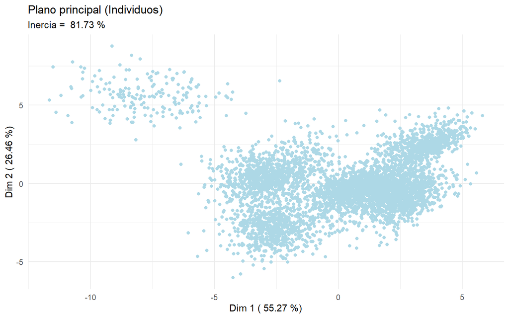

```r
plano_principal(beans_datos)
```

**Círculo de correlaciones**

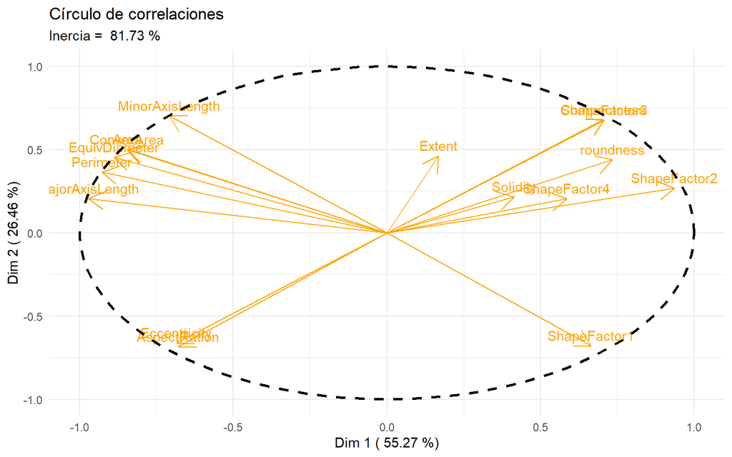

```r
circulo_correlaciones(beans_datos)$variables
```

**Gráfico Dual**

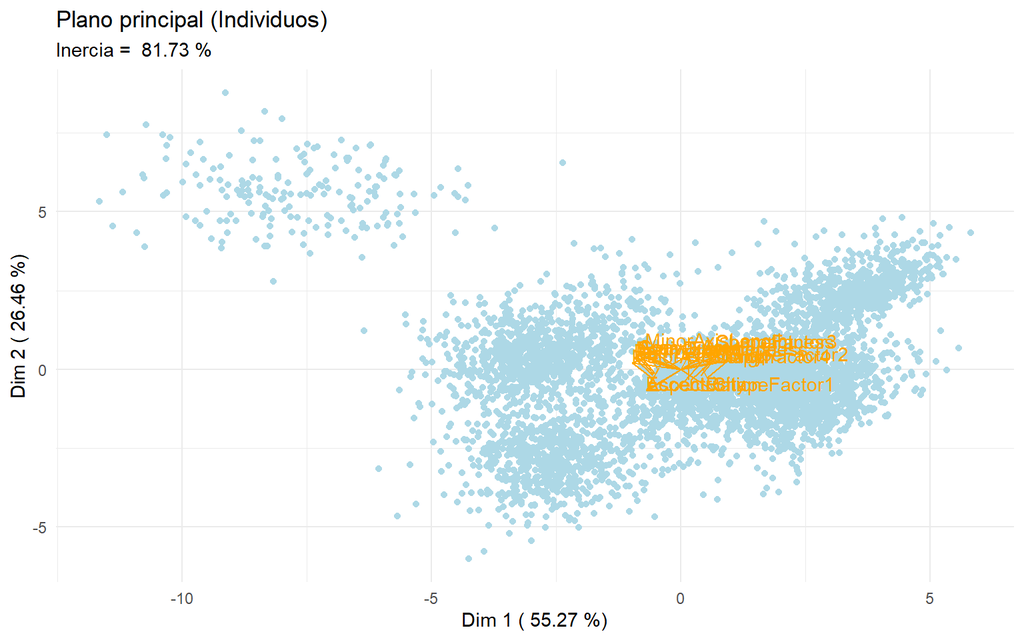

```r
grafico_dual(plano_principal(beans_datos),
             circulo_correlaciones(beans_datos), beans_datos)
```

### Inciso 4

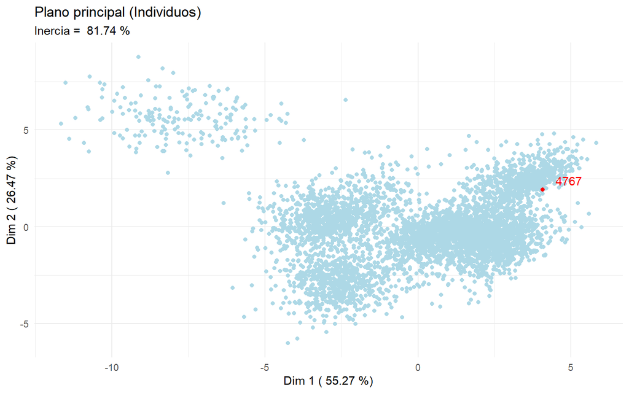

```r
fila_sup_beans <- beans_datos[6,]
coordenadasind_sup_beans <- ind.sup_proyeccion(fila_sup_beans, beans_datos[-6,])
coordenadasind_sup_beans
```

### Inciso 5

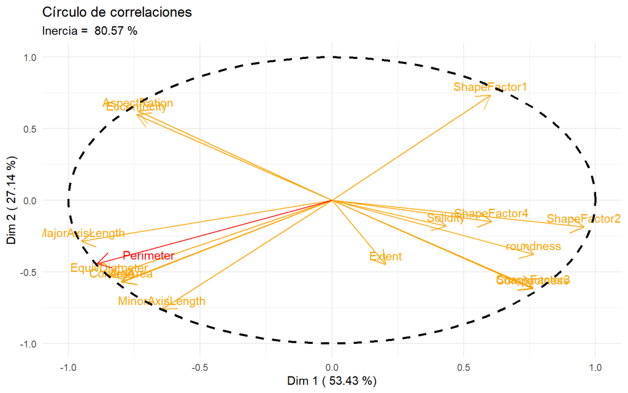

```r
columna_sup_beans <- as.matrix(beans_datos[,2])
colnames(columna_sup_beans) <- (colnames(beans_datos))[2]

coordenadasvar_sup_beans <- var.sup_proyeccion(columna_sup_beans, beans_datos[,-2])
coordenadasvar_sup_beans
```